# Análise Exploratória - Comparação entre vendedores de diferentes lojas

Daniel

2024-08-08

# Análise Exploratória - Comparação de Lojas de Diferentes Regiões

## Base de dados Employee

### Carregar dataset

```r
employee_dataset <- read_csv(file = 'employee_final.csv',locale = locale(encoding = "Latin1"))
head(employee_dataset)
```

| id_employee | name | surname | cpf | status | role | initial_date | end_date | store_id |
| --- | --- | --- | --- | --- | --- | --- | --- | --- |
| 643 | Antonella | da Cruz | 938.507.461-00 | ativo | gerente | 14/12/2007 | NA | MG_21 |
| 924 | Carlos Eduardo | Alves | 501.639.827-59 | ativo | vendedor | 29/09/2014 | NA | MG_21 |
| 567 | Ana Sophia | Ramos | 980.413.526-42 | ativo | vendedor | 03/04/2006 | NA | MG_21 |
| 660 | Marcela | Brito | 859.163.742-91 | ativo | vendedor | 14/03/2003 | NA | MG_21 |
| 297 | Leonardo | Porto | 652.341.890-15 | ativo | vendedor | 27/06/2021 | NA | MG_23 |
| 523 | Heitor | Sales | 472.395.061-34 | ativo | vendedor | 11/09/2021 | NA | MG_23 |

### Análise exploratória

#### Resumo Estatístico da Base

```r
summary(employee_dataset)
```

```
##   id_employee         name             surname              cpf
##  Min.   :   1.0   Length:920         Length:920         Length:920
##  1st Qu.: 248.8   Class :character   Class :character   Class :character
##  Median : 492.5   Mode  :character   Mode  :character   Mode  :character
##  Mean   : 497.5
##  3rd Qu.: 750.2
##  Max.   :1000.0
##     status              role           initial_date         end_date
##  Length:920         Length:920         Length:920         Length:920
##  Class :character   Class :character   Class :character   Class :character
##  Mode  :character   Mode  :character   Mode  :character   Mode  :character
##
##
##
##    store_id
##  Length:920
##  Class :character
##  Mode  :character
##
##
##
```

#### Estrutura da base

```r
str(employee_dataset)
```

```
## spc_tbl_ [920 × 9] (S3: spec_tbl_df/tbl_df/tbl/data.frame)
##  $ id_employee : num [1:920] 643 924 567 660 297 523 264 834 693 417 ...
##  $ name        : chr [1:920] "Antonella" "Carlos Eduardo" "Ana Sophia" "Marcela" ...
##  $ surname     : chr [1:920] "da Cruz" "Alves" "Ramos" "Brito" ...
##  $ cpf         : chr [1:920] "938.507.461-00" "501.639.827-59" "980.413.526-42" "859.163.742-91" ...
##  $ status      : chr [1:920] "ativo" "ativo" "ativo" "ativo" ...
##  $ role        : chr [1:920] "gerente" "vendedor" "vendedor" "vendedor" ...
##  $ initial_date: chr [1:920] "14/12/2007" "29/09/2014" "03/04/2006" "14/03/2003" ...
##  $ end_date    : chr [1:920] NA NA NA NA ...
##  $ store_id    : chr [1:920] "MG_21" "MG_21" "MG_21" "MG_21" ...
##  - attr(*, "spec")=
##   .. cols(
##   ..   id_employee = col_double(),
##   ..   name = col_character(),
##   ..   surname = col_character(),
##   ..   cpf = col_character(),
##   ..   status = col_character(),
##   ..   role = col_character(),
##   ..   initial_date = col_character(),
##   ..   end_date = col_character(),
##   ..   store_id = col_character()
##   .. )
##  - attr(*, "problems")=<externalptr>
```

#### Contagem de nulos na base de dados

```r
sapply(employee_dataset, function(x) sum(is.na(x)))
```

```
##  id_employee         name      surname          cpf       status         role
##            0            0            0            0            0            0
## initial_date     end_date     store_id
##            0          820            0
```

#### Transformar Coluna em Tipo Date

```r
employee_dataset$initial_date <- as.Date(employee_dataset$initial_date, format = "%d/%m/%Y")

employee_dataset$end_date <- as.Date(employee_dataset$end_date, format = "%d/%m/%Y")
```

## Base de dados Lojas

### Análise Exploratória

```r
store <- read.csv(file = 'store_final.csv')
head(store)
```

|  | nome_loja | regiao | diretoria | data_inauguracao |
| --- | --- | --- | --- | --- |
| 1 | SP Capital Sul_59 | SP Capital Sul | Grande SP | 09/08/2020 |
| 2 | SP Capital Sul_30 | SP Capital Sul | Grande SP | 05/03/2000 |
| 3 | SP Capital Sul_17 | SP Capital Sul | Grande SP | 28/02/2019 |
| 4 | SP Capital Sul_9 | SP Capital Sul | Grande SP | 16/05/2001 |
| 5 | SP Capital Sul_97 | SP Capital Sul | Grande SP | 12/07/2017 |
| 6 | SP Capital Sul_90 | SP Capital Sul | Grande SP | 15/04/2000 |

#### Resumo Estatístico da Base

```r
summary(store)
```

```
##   nome_loja            regiao           diretoria         data_inauguracao
##  Length:205         Length:205         Length:205         Length:205
##  Class :character   Class :character   Class :character   Class :character
##  Mode  :character   Mode  :character   Mode  :character   Mode  :character
```

#### Estrutura da base

```r
str(store)
```

```
## 'data.frame':    205 obs. of  4 variables:
##  $ nome_loja       : chr  "SP Capital Sul_59" "SP Capital Sul_30" "SP Capital Sul_17" "SP Capital Sul_9" ...
##  $ regiao          : chr  "SP Capital Sul" "SP Capital Sul" "SP Capital Sul" "SP Capital Sul" ...
##  $ diretoria       : chr  "Grande SP" "Grande SP" "Grande SP" "Grande SP" ...
##  $ data_inauguracao: chr  "09/08/2020" "05/03/2000" "28/02/2019" "16/05/2001" ...
```

#### Contagem de nulos na base de dados

```r
sapply(store, function(x) sum(is.na(x)))
```

```
##        nome_loja           regiao        diretoria data_inauguracao
##                0                0                0                0
```

#### Transformar Coluna em Tipo Date

```r
store$data_inauguracao <- as.Date(store$data_inauguracao, format = "%d/%m/%Y")
```

## Base de dados Transações

### Análise Exploratória

```r
dataset_2024 <- read.csv(file = 'transaction_fact_v3_2024.csv')
head(dataset_2024)
```

|  | data | cod_vendedor | cod_loja | cod_transacao | quantidade | cod_prod | preco |
| --- | --- | --- | --- | --- | --- | --- | --- |
| 1 | 2024-05-29 | 917 | SP Capital Centro_48 | 000484fc7c | 1 | 917845373827 | 88.60280 |
| 2 | 2024-05-31 | 58 | SP Capital Centro_99 | 0012fb5659 | 2 | 705516174930 | 123.62559 |
| 3 | 2024-05-31 | 58 | SP Capital Centro_99 | 0012fb5659 | 1 | 715775125765 | 66.96472 |
| 4 | 2024-05-31 | 287 | SP Interior_32 | 001af83ace | 1 | 336847961663 | 66.96472 |
| 5 | 2024-05-30 | 371 | SP Capital Centro_11 | 0026881cb2 | 2 | 426037160751 | 144.23329 |
| 6 | 2024-05-29 | 534 | RJ_57 | 003449351c | 4 | 814394039436 | 440.96355 |

#### Resumo Estatístico da Base

```r
summary(dataset_2024)
```

```
##      data            cod_vendedor      cod_loja         cod_transacao
##  Length:290525      Min.   :   2.0   Length:290525      Length:290525
##  Class :character   1st Qu.: 250.0   Class :character   Class :character
##  Mode  :character   Median : 481.0   Mode  :character   Mode  :character
##                     Mean   : 496.3
##                     3rd Qu.: 751.0
##                     Max.   :1000.0
##    quantidade      cod_prod             preco
##  Min.   :1.00   Min.   :6.587e+09   Min.   :  12.20
##  1st Qu.:1.00   1st Qu.:2.605e+11   1st Qu.:  65.92
##  Median :2.00   Median :5.539e+11   Median : 113.33
##  Mean   :2.11   Mean   :5.264e+11   Mean   : 201.99
##  3rd Qu.:3.00   3rd Qu.:7.857e+11   3rd Qu.: 211.73
##  Max.   :4.00   Max.   :9.885e+11   Max.   :2312.57
```

#### Estrutura da base

```r
str(dataset_2024)
```

```
## 'data.frame':    290525 obs. of  7 variables:
##  $ data         : chr  "2024-05-29" "2024-05-31" "2024-05-31" "2024-05-31" ...
##  $ cod_vendedor : int  917 58 58 287 371 534 634 634 108 897 ...
##  $ cod_loja     : chr  "SP Capital Centro_48" "SP Capital Centro_99" "SP Capital Centro_99" "SP Interior_32" ...
##  $ cod_transacao: chr  "000484fc7c" "0012fb5659" "0012fb5659" "001af83ace" ...
##  $ quantidade   : int  1 2 1 1 2 4 4 1 2 2 ...
##  $ cod_prod     : num  9.18e+11 7.06e+11 7.16e+11 3.37e+11 4.26e+11 ...
##  $ preco        : num  88.6 123.6 67 67 144.2 ...
```

#### Contagem de nulos na base de dados

```r
sapply(dataset_2024, function(x) sum(is.na(x)))
```

```
##          data  cod_vendedor      cod_loja cod_transacao    quantidade
##             0             0             0             0             0
##      cod_prod         preco
##             0             0
```

#### Transformar Coluna em Tipo Date

```r
dataset_2024$data <- as.Date(dataset_2024$data, format = "%Y-%m-%d")
```

## União das bases de dados

```r
dataset_final <- sqldf("
  SELECT
    t.data,
    t.cod_vendedor,
    CONCAT(e.name,' ',e.surname) AS nome_vendedor,
    e.status AS status_vendedor,
    e.role AS role_vendedor,
    t.cod_loja,
    t.cod_transacao,
    t.quantidade,
    t.cod_prod,
    t.preco,
    s.regiao,
    s.diretoria

  FROM dataset_2024 t
  LEFT JOIN store s
  ON t.cod_loja = s.nome_loja
  LEFT JOIN employee_dataset e
  ON t.cod_vendedor = e.id_employee
  ORDER BY
    t.cod_transacao
")
dataset_final
```

| data | cod_vendedor | nome_vendedor | status_vendedor | role_vendedor | cod_loja | cod_transacao | quantidade | cod_prod | preco | regiao | diretoria |
| --- | --- | --- | --- | --- | --- | --- | --- | --- | --- | --- | --- |
| 2024-01-30 | 476 | Isaac Moreira | ativo | vendedor | SP Capital Sul_93 | 00012db3a5 | 1 | 839689622605 | 35.10605 | SP Capital Sul | Grande SP |
| 2024-01-30 | 476 | Isaac Moreira | ativo | vendedor | SP Capital Sul_93 | 00012db3a5 | 1 | 608058692101 | 110.21487 | SP Capital Sul | Grande SP |
| 2024-01-30 | 523 | Heitor Sales | ativo | vendedor | MG_23 | 0001f31dfc | 1 | 669865728414 | 200.93070 | MG | SP Interior/Sudeste |
| 2024-01-30 | 523 | Heitor Sales | ativo | vendedor | MG_23 | 0001f31dfc | 3 | 915865504351 | 828.11854 | MG | SP Interior/Sudeste |
| 2024-01-30 | 523 | Heitor Sales | ativo | vendedor | MG_23 | 0001f31dfc | 1 | 721972741868 | 47.78676 | MG | SP Interior/Sudeste |
| 2024-01-30 | 523 | Heitor Sales | ativo | vendedor | MG_23 | 0001f31dfc | 2 | 213859277084 | 37.04718 | MG | SP Interior/Sudeste |
| 2024-01-30 | 523 | Heitor Sales | ativo | vendedor | MG_23 | 0001f31dfc | 1 | 650578539121 | 31.20430 | MG | SP Interior/Sudeste |
| 2024-01-30 | 523 | Heitor Sales | ativo | vendedor | MG_23 | 0001f31dfc | 3 | 471402392732 | 43.86550 | MG | SP Interior/Sudeste |
| 2024-01-30 | 523 | Heitor Sales | ativo | vendedor | MG_23 | 0001f31dfc | 3 | 774110995142 | 149.21292 | MG | SP Interior/Sudeste |
| 2024-01-30 | 523 | Heitor Sales | ativo | vendedor | MG_23 | 0001f31dfc | 1 | 798625838862 | 424.30626 | MG | SP Interior/Sudeste |

[output cut: 9990 more lines]

#### Análise da Quantidade de Produtos Vendidos por Região e Diretoria

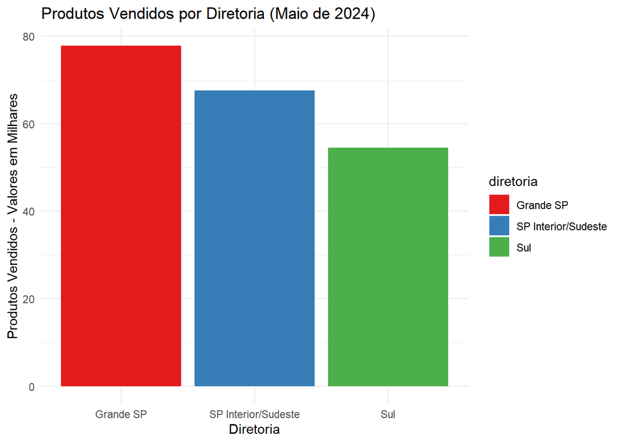

```r
dataset_maio <- dataset_final %>%
  filter(month(data) == 5 & year(data) == 2024)


media_produtos_por_diretoria <- dataset_maio %>%
  group_by(diretoria) %>%
  summarise(media_quantidade = sum(quantidade, na.rm = TRUE) / 1000) %>%
  ungroup()


grafico_diretoria <- ggplot(media_produtos_por_diretoria, aes(y = media_quantidade, x = diretoria, fill = diretoria)) +
    geom_bar(stat = "identity") +
    labs(title = "Produtos Vendidos por Diretoria (Maio de 2024)",
         x = "Diretoria", y = "Produtos Vendidos - Valores em Milhares") +
    theme_minimal() +
    scale_fill_brewer(palette = "Set1")

media_produtos_por_regiao <- dataset_maio %>%
  group_by(regiao, diretoria) %>%
  summarise(media_quantidade = sum(quantidade, na.rm = TRUE) / 1000) %>%
  ungroup()
grafico_regiao <- ggplot(media_produtos_por_regiao, aes(fill = diretoria, y = regiao, x = media_quantidade)) +
    geom_bar(position = "stack", stat = "identity") +
    labs(title = "Produtos Vendidos por Região (Maio de 2024)",
         x = "Produtos Vendidos - Valores em Milhares", y = "Região") +
    theme_minimal() +
    scale_fill_brewer(palette = "Set1")

print(grafico_diretoria)
```

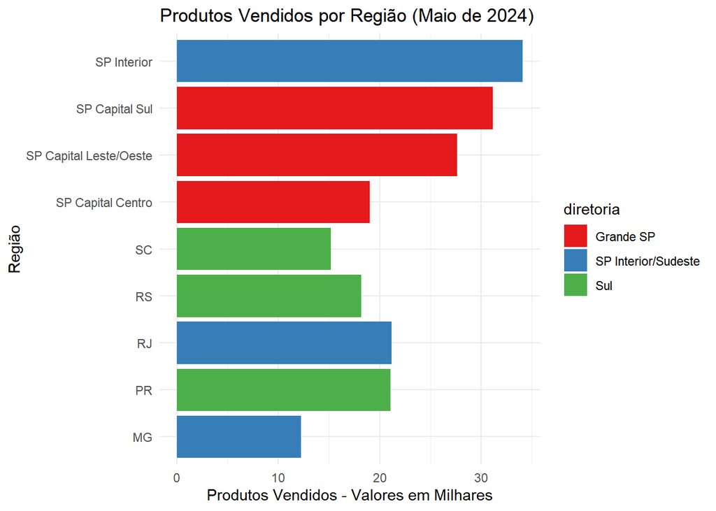

```r
print(grafico_regiao)
```

#### Análise de Faturamento por Região e Diretoria

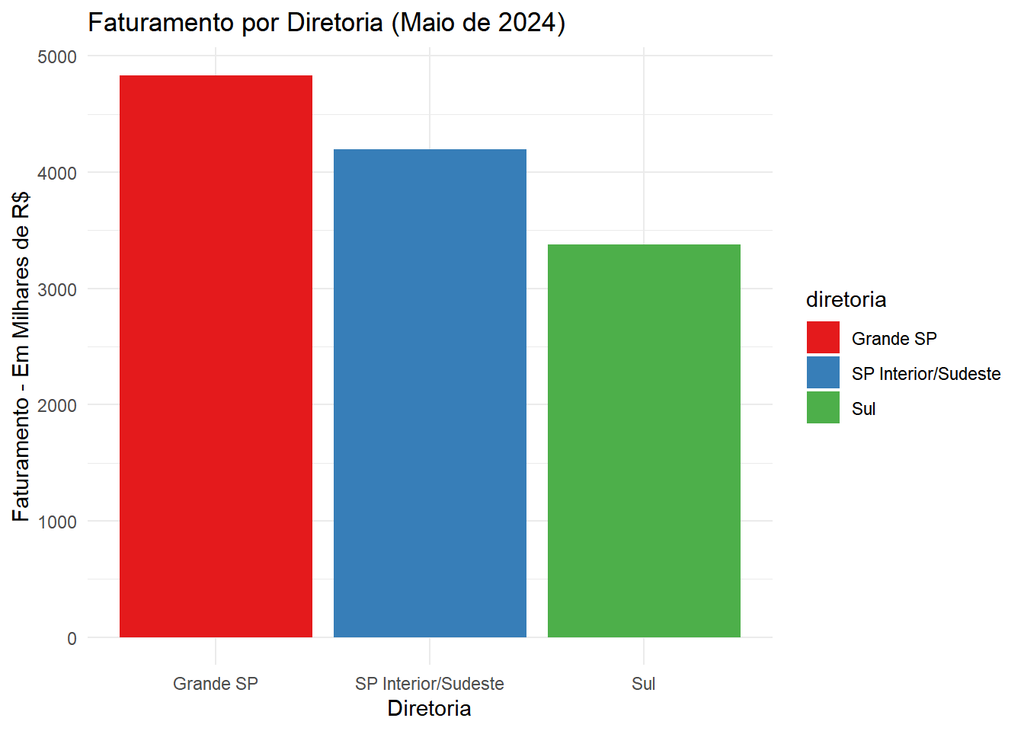

```r
dataset_maio <- dataset_final %>%
  filter(month(data) == 5 & year(data) == 2024)


media_produtos_por_diretoria <- dataset_maio %>%
  group_by(diretoria) %>%
  summarise(media_quantidade =  sum(preco, na.rm = TRUE) / 1000) %>%
  ungroup()



grafico_diretoria <- ggplot(media_produtos_por_diretoria, aes(y = media_quantidade, x = diretoria, fill = diretoria)) +
    geom_bar(stat = "identity") +
    labs(title = "Faturamento por Diretoria (Maio de 2024)",
         x = "Diretoria", y = "Faturamento - Em Milhares de R$") +
    theme_minimal() +
    scale_fill_brewer(palette = "Set1")

media_produtos_por_regiao <- dataset_maio %>%
  group_by(regiao, diretoria) %>%
  summarise(media_quantidade =  sum(preco, na.rm = TRUE) / 1000) %>%
  ungroup()
grafico_regiao <- ggplot(media_produtos_por_regiao, aes(fill = diretoria, y = regiao, x = media_quantidade)) +
    geom_bar(position = "stack", stat = "identity") +
    labs(title = "Faturamento por Região (Maio de 2024)",
         x = "Faturamento - Em Milhares de R$", y = "Região") +
    theme_minimal() +
    scale_fill_brewer(palette = "Set1")

print(grafico_diretoria)
```

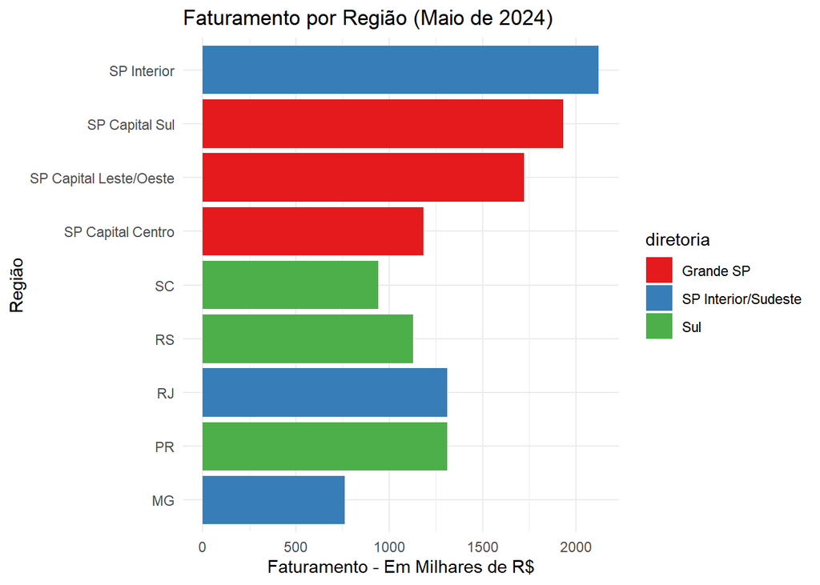

```r
print(grafico_regiao)
```

#### Ticket Médio Distribuido por Região e Diretoria

```r
faturamento_por_transacao <- dataset_maio %>%
  group_by(cod_transacao, regiao, diretoria) %>%
  summarise(
    faturamento_transacao = sum(preco, na.rm = TRUE)
  ) %>%
  ungroup()
ticket_medio_regiao_diretoria <- faturamento_por_transacao %>%
  group_by(regiao, diretoria) %>%
  summarise(
    ticket_medio = mean(faturamento_transacao, na.rm = TRUE)
  ) %>%
  ungroup()
print(faturamento_por_transacao)
```

```
## # A tibble: 18,052 × 4
##    cod_transacao regiao                 diretoria          faturamento_transacao
##    <chr>         <chr>                  <chr>                              <dbl>
##  1 000484fc7c    SP Capital Centro      Grande SP                           929.
##  2 0007242f3f    SP Capital Leste/Oeste Grande SP                           301.
##  3 0012fb5659    SP Capital Centro      Grande SP                           976.
##  4 00159cc227    SP Interior            SP Interior/Sudes…                  297.
##  5 0016dd462a    SP Capital Centro      Grande SP                           192.
##  6 001af83ace    SP Interior            SP Interior/Sudes…                  489.
##  7 001ded4163    RS                     Sul                                 590.
##  8 0026881cb2    SP Capital Centro      Grande SP                           583.
##  9 002f483cb2    SP Interior            SP Interior/Sudes…                  612.
## 10 003449351c    RJ                     SP Interior/Sudes…                 1549.
## # ℹ 18,042 more rows
```

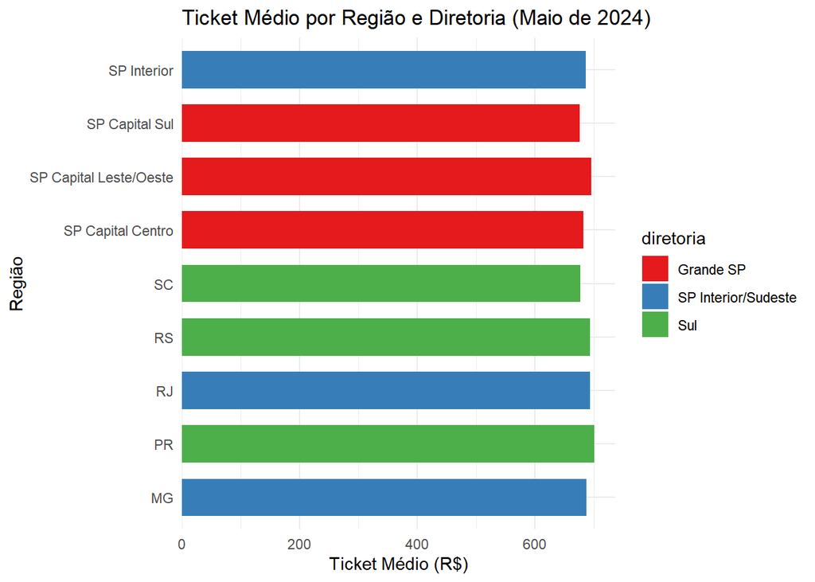

```r
grafico_ticket_medio <- ggplot(ticket_medio_regiao_diretoria, aes(x = ticket_medio, y = regiao, fill = diretoria)) +
  geom_bar(stat = "identity", position = "dodge", width = 0.7) +
  labs(title = "Ticket Médio por Região e Diretoria (Maio de 2024)",
       x = "Ticket Médio (R$)", y = "Região") +
  theme_minimal() +
  scale_fill_brewer(palette = "Set1") +
  scale_x_continuous(expand = expansion(mult = c(0, 0.05)))

print(grafico_ticket_medio)
```

#### Análise para Verificar se o Gerente possui Vendas

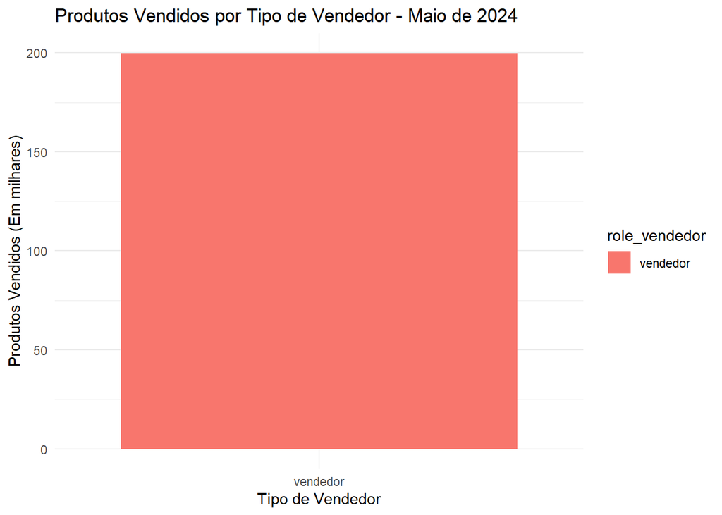

```r
df_maio <- dataset_final %>%
  filter(month(data) == 5 & year(data) == 2024)  # Filtrando para maio de 2024

# Agrupar por role_vendedor e calcular a média da quantidade vendida
df_maio_avg <- df_maio %>%
  group_by(role_vendedor) %>%
  summarise(media_quantidade_vendida = sum(quantidade, na.rm = TRUE)/1000)

# Gerar gráfico de barras
ggplot(df_maio_avg, aes(x = role_vendedor, y = media_quantidade_vendida, fill = role_vendedor)) +
  geom_bar(stat = "identity") +
  labs(title = "Produtos Vendidos por Tipo de Vendedor - Maio de 2024",
       x = "Tipo de Vendedor",
       y = "Produtos Vendidos (Em milhares)") +
  theme_minimal()
```

## Conclusão

### Descobertas

Ao examinar as tabelas, percebi que as colunas de datas estavam no formato chr, então as converti para o formato date para melhorar as visualizações durante a análise.

Contudo, ao observar o ticket médio, nota-se que, apesar das vendas serem maiores na região de São Paulo, o ticket médio se mantém estável em todas as regiões, sugerindo uma similaridade no perfil dos clientes em diferentes áreas.

### Discussões

As análises geradas abrem discussões sobre a importância de disponibilizar essas visualizações para vendedores e gerentes de lojas. Uma provocação que a análise traz é a possibilidade de desenvolver visualizações voltadas para o nível gerencial da empresa, auxiliando nas tomadas de decisão.

Outro ponto de discussão levantado pela análise foi a verificação de vendas realizadas por gerentes. Os dados mostram que apenas os vendedores estão efetuando vendas. No entanto, essa conclusão só foi possível após a correção das bases de dados, pois, anteriormente, analisávamos dados que indicavam vendas feitas por gerentes. Com essa atualização, os dados passaram a fazer mais sentido, eliminando a complexidade de incluir comissões de vendas para os gerentes, o que simplifica o cálculo da remuneração.